# 생존분석

Growth Hackers

**라이브러리**

```r
library(KMsurv)
library(survival)
library(ggplot2)
library(survminer)
library(car) #vif 할때 쓰임
library(maxstat) #cutpoint 찾을 때 쓰임
library(party) #cutpoint 찾을 떄 쓰임
```

**데이터 불러오기**

```r
df = read.csv('E:/Growth Hackers/2019-2/project_bank/result_survival.csv',header=T)
```

# 1 전처리

## 1.1 생존분석을 위한 데이터 형태로 변환

새로 생기는 변수는 다음과 같다

- failure: 부도이면 1, 부도가 아니면 0
- time: 기업설립일로부터 부도날짜(현재 날짜) 까지의 기간

```r
#fail(부도) 여부 변수 생성
df[,"failure"] = ifelse(is.na(df$suspension_date),0,1)

#suspension_date 가 없는 경우 최근 날짜 입력 -> censoring 표시 위해
df$suspension_date = ifelse(is.na(df$suspension_date),"20200205",df$suspension_date)

#establish_date 를 character 로 변환 (날짜로 바꿀떄 char 에서 date 로 바꿔야 해서)
df$establish_date=as.character(df$establish_date)

#기업 설립일으로 부터 부도 날짜(현재)까지 기간 time 변수 생성
df[,"time"] = as.integer(as.Date(df$suspension_date,format="%Y%m%d")-as.Date(df$establish_date,format = "%Y%m%d"))
head(df$time)
```

```
## [1]  3015  2087 12108  5201  6036 10262
```

## 1.2 KNN으로 검증된 변수 선택

```r
colnames(df)
```

```
##  [1] "ked_code"                    "business_number"
##  [3] "establish_date"              "avg_credit_payment_ratio"
##  [5] "avg_credit_payment_period"   "credit_grade"
##  [7] "suspension_date"             "avg_working_year"
##  [9] "avg_employee_count"          "avg_rent_deposite"
## [11] "site_post_number"            "average_yearly_salary_total"
## [13] "average_working_year_total"  "per_share_par_value"
## [15] "share_holders_count"         "avg_company_size"
## [17] "company_status"              "listing_YN"
## [19] "recent_date"                 "accounts_receivable"
## [21] "asset"                       "debt"
## [23] "net_income"                  "non_current_liabilities"
## [25] "operating_profit"            "sales"
## [27] "failure"                     "time"
```

```r
#
data=df[,c("ked_code","business_number","debt","accounts_receivable","avg_credit_payment_ratio","share_holders_count","non_current_liabilities","operating_profit","failure","time")]
```

**결측치 제거**

```r
data<-na.omit(data)
```

**참고) 부도 난 기업과 부도나지 않은 기업의 비율 확인**

```r
table(data[,"failure"])
```

```
##
##   0   1
## 282 288
```

# 2 VIF

다중공산성은 종속변수 Y에 대해 설명변수들 간 강한 상관관계로부터 나온다.  
다중공산성 문제를 사전에 방지하기 위한 다양한 진단법 중 하나가 분산팽창계수를 계산하여 분산팽창요인(Variance Inflation Factor, VIF) 를 찾는 것이다.

**설명변수 고르기**

```r
vif_check<-subset(data,select=-c(ked_code, business_number,failure))
```

**종속변수(time) 과 설명변수 회귀분석**

```r
lmfit<-lm(time~ . , data=vif_check)
#회귀 결과 확인하고 싶다면 아래 코드 진행
#summary(lmfit)
```

**vif** 회귀 결과 vif 가 10 초과이면 다중공산성이 존재한다.

```r
vif(lmfit)
```

```
##                     debt      accounts_receivable avg_credit_payment_ratio
##              7154.809336                 2.509102                 1.005659
##      share_holders_count  non_current_liabilities         operating_profit
##                 1.008325                 2.831890              7137.274994
```

```r
#vif 값이 10 초과인지 TRUE/FALSE
a<-vif(lmfit)>10
#vif 값이 10 이하 인 변수만을 가져와라
vif_variable<-rownames(data.frame(a[a==FALSE]))
#data에 vif 결과 FALSE 인 변수들만 남도록
data<-data[,c("ked_code", "business_number","failure","time",vif_variable)]
colnames(data)
```

```
## [1] "ked_code"                 "business_number"
## [3] "failure"                  "time"
## [5] "accounts_receivable"      "avg_credit_payment_ratio"
## [7] "share_holders_count"      "non_current_liabilities"
```

# 3 전체 데이터 기준 생존함수

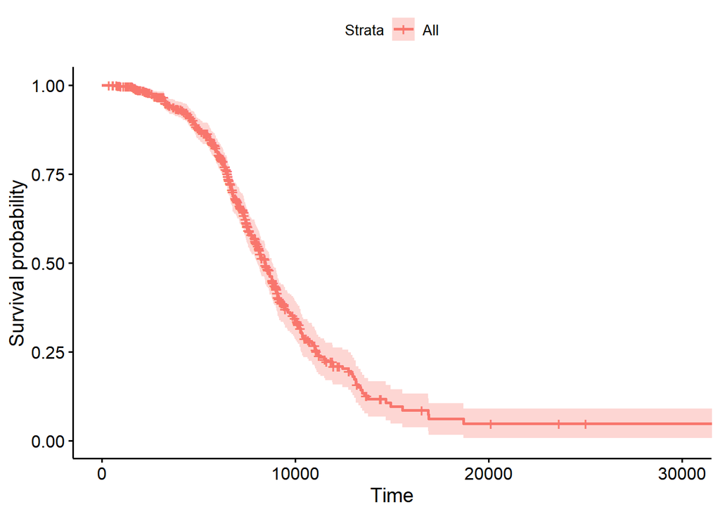

```r
surv_data = Surv(time=data$time,event=data$failure)
ggsurvplot(survfit(formula=surv_data~1,data=surv_data,conf.type="plain"))
```

# 4 단변량 분석

단변량 분석은 각 변수별로 유의성을 알아보기 위해 log-rank test 를 진행한다.  
log-rank test 를 진행하기 위해서는 연속형 변수를 범주형 변수로 변환해야하는데,  
이 방법으로는 maximally selected rank statistics를 이용한다.

아래 식을 귀무가설로 설정하고, log-rank statistic 값이 일정 값보다 크면 귀무가설 기각한다.
$$H_0: P(Y\le y | X \le \mu) = P(Y\le y | X > \mu)$$
maximally selected rank statistics 는 귀무가설을 기각할 수 있는 log-rank statistic 이 가장 크게 나오는 값을 찾아준다.
이 값을 cutpoint($\mu$) 로 여겨 연속형 변수를 범주형 변수로 바꿀 것이다.

## 4.1 accounts_receivable

### 4.1.1 연속형변수 범주형으로 바꾸기

**연속형변수 범주형으로 바꿀 cutpoint 찾기**

```r
mstat<-maxstat.test(Surv(time,failure)~accounts_receivable,data=data,smethod="LogRank",pmethod="exactGauss",abseps=0.01)

mstat
```

```
##
## Maximally selected LogRank statistics using exactGauss
##
## data:  Surv(time, failure) by accounts_receivable
## M = 4.7079, p-value = 0.0001449
## sample estimates:
## estimated cutpoint
##             509091
```

maximally selected rank statistics 결과 accounts_receivable 의 cutpoint 는 509091 이다. 확인을 위해서 log-rank statistic 을 그래프로 그려보면, 509091 에서 log-rank statistic 값이 가장 큰걸 확인할 수 있다.

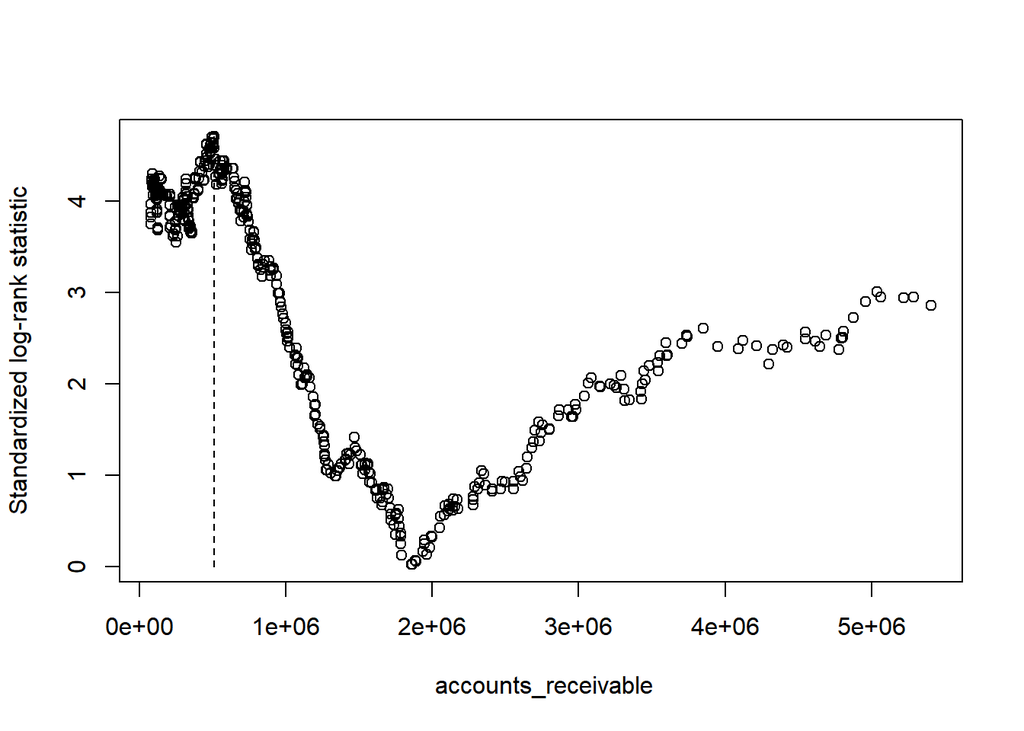

```r
plot(mstat)
```

**cutpoint 를 기준으로 범주형 데이터로 생존함수 그려보자**

```r
gp_ar<-ifelse(data$accounts_receivable<=mstat$estimate, 0,1)

gp_ar<-factor(gp_ar)
table(gp_ar)
```

```
## gp_ar
##   0   1
## 209 361
```

gp_ar 이 위와 같이 잘 나뉜것을 확인 할 수 있다.

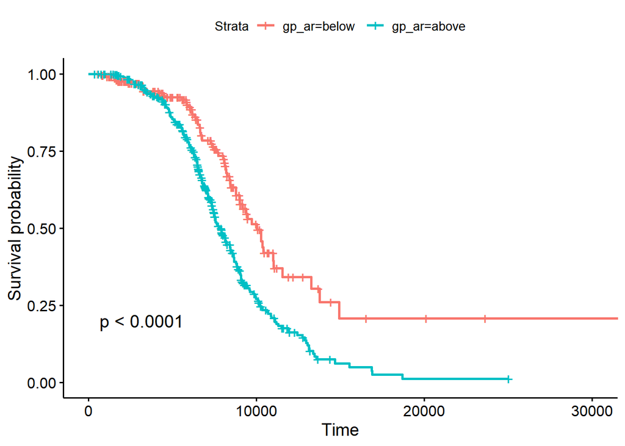

```r
levels(gp_ar)<-c("below ", "above")
fit<-survfit(surv_data~gp_ar,data=data)
ggsurvplot(fit,data=data,pval=TRUE)
```

logranktest에 대한 p value 가 0.05보다 작으므로, accounts_receivable 변수는 유의미하다.

### 4.1.2 time dependency check

추후의 다변량 분석 방법을 정하기 위해서는 time dependency 를 알아봐야한다.  
만약 time dependent 한 변수가 있다면 time dependent cox regression 모델을 적용해야하고,  
time dependent 한 변수가 없다면 cox-ph 를 적용한다.

lml curv 를 그렸을때 그래프가 교차하는 경우 시간에 따라서 hazard ratio 가 다르다는 뜻으로, time depent 변수라는 것이다.

추후에 time dependent cox regression 모델을 적용하기 위해  
변수가 어느 시간을 기준으로 hazard ratio 가 달라지는지 알아보자.

**lml curv**

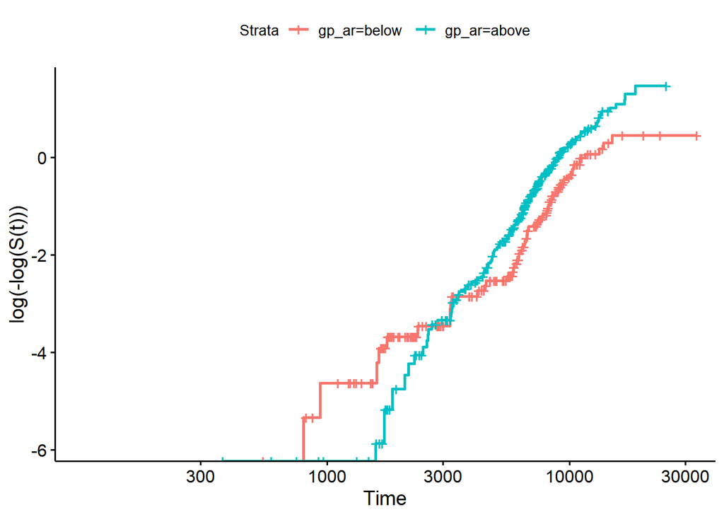

```r
ggsurvplot(fit,data=data, fun="cloglog",xlim=c(100,30000))
```

두 그래프가 교차한다. 따라서 accounts_receivable는 time dependent variable

**splitpoint 확인**

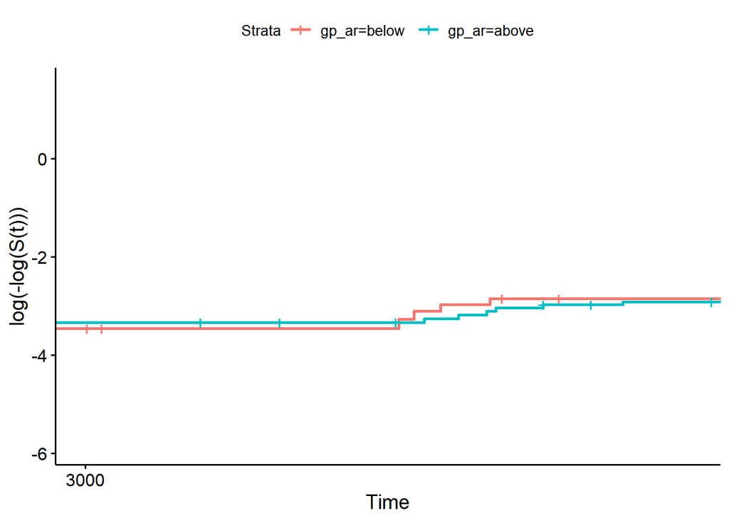

```r
ggsurvplot(fit,data=data, fun="cloglog",xlim=c(3000,3400))
```

```r
#splitpoint 3200
```

## 4.2 avg_credit_payment_ratio

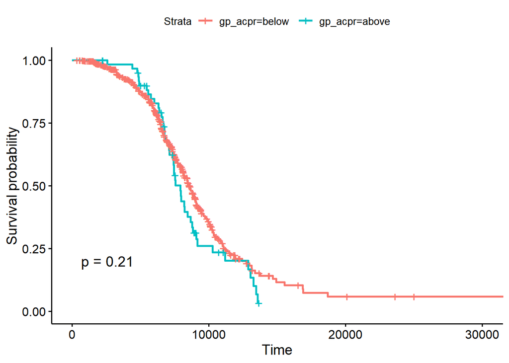

```r
mstat<-maxstat.test(Surv(time,failure)~avg_credit_payment_ratio,data=data,smethod="LogRank",pmethod="exactGauss",abseps=0.01)

gp_acpr<-ifelse(data$avg_credit_payment_ratio<=mstat$estimate, 0,1)
gp_acpr<-factor(gp_acpr)
levels(gp_acpr)<-c("below ", "above")

fit<-survfit(surv_data~gp_acpr,data=data)
ggsurvplot(fit,data=data,pval=TRUE)
```

p-value 가 0.05보다 크므로 avg_credit_payment_ratio 는 유의미한 변수가 아니다.

## 4.3 share_holders_count

아래 코드도 같은 원리로 작동되는데, 그래프가 다르게 나옵니다.  
(이유는 모르겠지만 앞서 작성한 코드가 에러 났어요.  
Error in cmaxstat(scores, x, weights = weights, pmethod, minprop, maxprop, : no data between minprop, maxprop)

```r
test<-ctree(Surv(time,failure)~share_holders_count,data=data)
test
```

```
##
##   Conditional inference tree with 2 terminal nodes
##
## Response:  Surv(time, failure)
## Input:  share_holders_count
## Number of observations:  570
##
## 1) share_holders_count <= 1; criterion = 1, statistic = 13.304
##   2)*  weights = 530
## 1) share_holders_count > 1
##   3)*  weights = 40
```

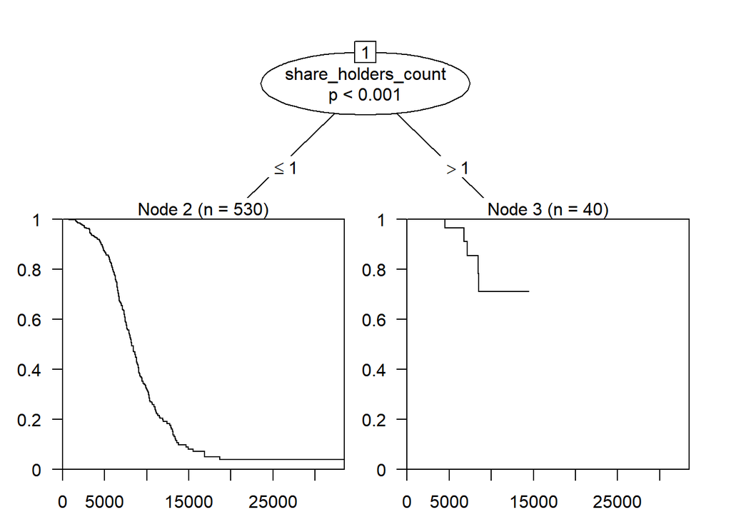

```r
plot(test)
```

p-value 가 0.05보다 작으므로 share_holders_count 는 유의미한 변수입니다.

### 4.3.1 time dependency check

**lml curv**

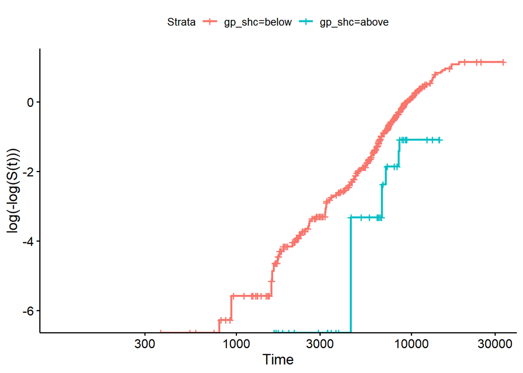

```r
gp_shc<-ifelse(data$share_holders_count<=1, 0,1)
gp_shc<-factor(gp_shc)
levels(gp_shc)<-c("below", "above")

fit<-survfit(surv_data~gp_shc,data=data)
ggsurvplot(fit,data=data, fun="cloglog",xlim=c(100,30000))
```

두 그래프가 교차하지 않는다. 따라서 share_holders_count는 time independent variable

## 4.4 non_current_liabilities

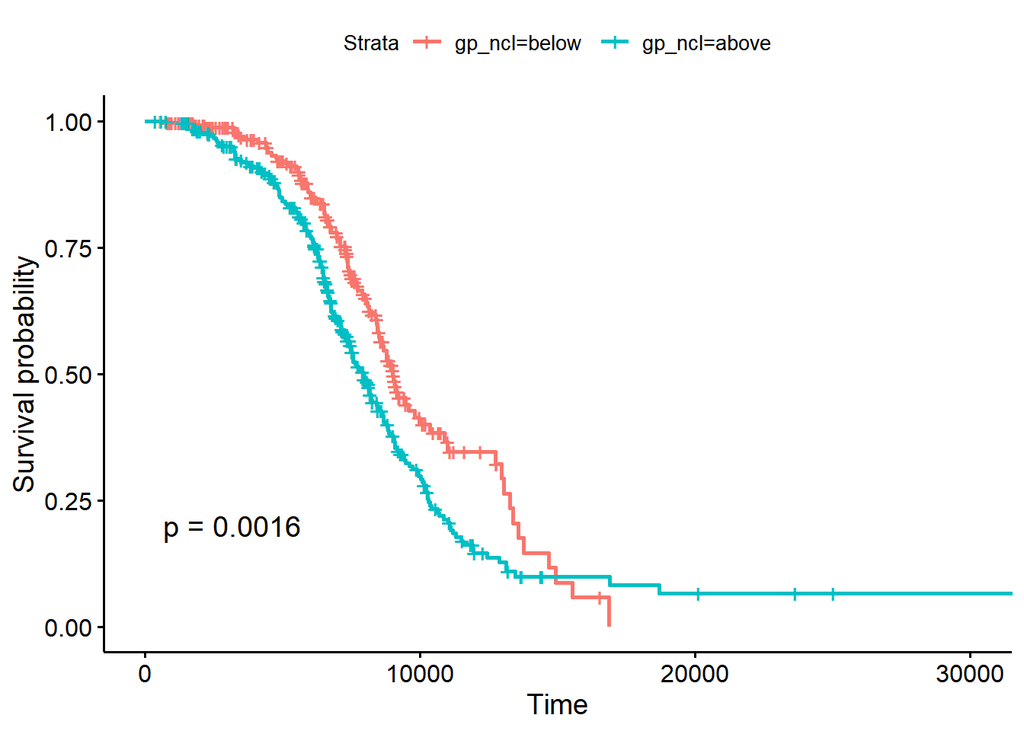

```r
mstat<-maxstat.test(Surv(time,failure)~non_current_liabilities,data=data,smethod="LogRank",pmethod="exactGauss",abseps=0.01)

gp_ncl<-ifelse(data$non_current_liabilities<=mstat$estimate, 0,1)
gp_ncl<-factor(gp_ncl)
levels(gp_ncl)<-c("below ", "above")

fit<-survfit(surv_data~gp_ncl,data=data)
ggsurvplot(fit,data=data,pval=TRUE)
```

p-value 가 0.05보다 작으므로 non_current_liabilities 는 유의미한 변수입니다.

### 4.4.1 time dependency check

**lml curv**

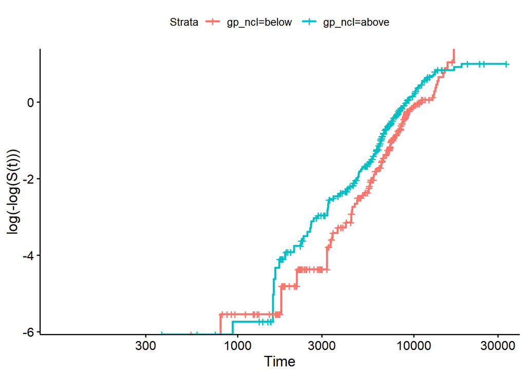

```r
ggsurvplot(fit,data=data, fun="cloglog",xlim=c(100,30000))
```

두 그래프가 교차한다. 따라서 non_current_liabilities는 time dependent variable

**splitpoint 확인**

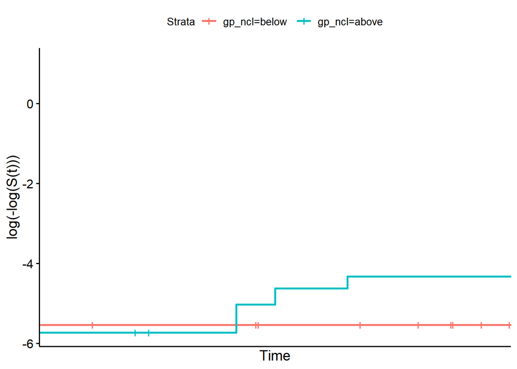

```r
ggsurvplot(fit,data=data, fun="cloglog",xlim=c(1500,1700))
```

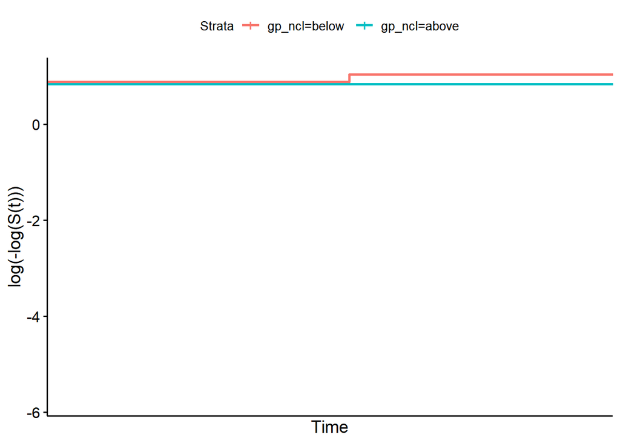

```r
#splitpoint 1600
ggsurvplot(fit,data=data, fun="cloglog",xlim=c(15000,16000))
```

```r
#splitpoint 15500
```

# 5 다변량분석

단변량 분석에서 유의미하지 않다고 판단된 avg_credit_payment_ratio 변수를 지운다.

```r
data<-subset(data,select=-c(avg_credit_payment_ratio))
colnames(data)
```

```
## [1] "ked_code"                "business_number"
## [3] "failure"                 "time"
## [5] "accounts_receivable"     "share_holders_count"
## [7] "non_current_liabilities"
```

## 5.1 time dependent cox regression

단변량 분석 결과 요약: share_holders_count 는 time independent,  
그 외 변수 (accounts_receivable, avg_credit_payment_ratio(유의미하지 않은 변수),non_current_liabilities) 는 time dependent 이다.

share_holders_count 랑 다른 변수랑 같이 time dependent cox regression 하면 에러 뜸

(Ran out of iterations and did not converge)

```r
new<-survSplit(Surv(time,failure)~.,data, cut=c(1600,3200,15500),episode='tgroup',id='id')
#accounts_receivable 3200
#non_current_liabilities 1600, 15500

coxph(Surv(tstart,time,failure)~accounts_receivable:strata(tgroup)+non_current_liabilities:strata(tgroup),data=new)
```

```
## Call:
## coxph(formula = Surv(tstart, time, failure) ~ accounts_receivable:strata(tgroup) +
##     non_current_liabilities:strata(tgroup), data = new)
##
##                                                      coef  exp(coef)
## accounts_receivable:strata(tgroup)tgroup=1     -1.757e-06  1.000e+00
## accounts_receivable:strata(tgroup)tgroup=2     -2.576e-08  1.000e+00
## accounts_receivable:strata(tgroup)tgroup=3     -2.658e-08  1.000e+00
## accounts_receivable:strata(tgroup)tgroup=4      5.012e-08  1.000e+00
## strata(tgroup)tgroup=1:non_current_liabilities  4.706e-08  1.000e+00
## strata(tgroup)tgroup=2:non_current_liabilities  1.799e-09  1.000e+00
## strata(tgroup)tgroup=3:non_current_liabilities  8.527e-09  1.000e+00
## strata(tgroup)tgroup=4:non_current_liabilities -1.268e-07  1.000e+00
##                                                  se(coef)      z      p
## accounts_receivable:strata(tgroup)tgroup=1      1.355e-06 -1.297 0.1947
## accounts_receivable:strata(tgroup)tgroup=2      7.111e-08 -0.362 0.7172
## accounts_receivable:strata(tgroup)tgroup=3      1.171e-08 -2.269 0.0233
## accounts_receivable:strata(tgroup)tgroup=4      8.494e-08  0.590 0.5551
## strata(tgroup)tgroup=1:non_current_liabilities  1.025e-07  0.459 0.6460
## strata(tgroup)tgroup=2:non_current_liabilities  3.740e-08  0.048 0.9616
## strata(tgroup)tgroup=3:non_current_liabilities  7.598e-09  1.122 0.2618
## strata(tgroup)tgroup=4:non_current_liabilities  1.468e-07 -0.864 0.3879
##
## Likelihood ratio test=13.25  on 8 df, p=0.1035
## n= 1599, number of events= 288
```

time dependent 변수의 cox regression 결과를 분석해보면, accounts_receivable이 tgroup 3 에 있는 경우의 p value 만 0.05 보다 작기 때문에, 이 결과만 유의미하다.

exp(coef) 가 아래 식에서 $exp(\beta^TZ)$ 에 해당하는 값이고, coef 는 $\beta$ 에 해당하는 값이다.  
$\beta$ 가 음수 이므로, tgroup3($3200<t \le 15500$)의 accounts_receivable 이 증가하면,  
부도확률은 낮아진다.  
하지만 비율($exp(\beta^TZ)$)을 고려했을때 낮아지는 정도는 아주 미세하다.

$$h(t|Z)=h_0(t)exp(\beta^TZ)$$

```r
coxph(Surv(time,failure)~share_holders_count,data=data)
```

```
## Call:
## coxph(formula = Surv(time, failure) ~ share_holders_count, data = data)
##
##                        coef exp(coef) se(coef)      z       p
## share_holders_count -0.3521    0.7032   0.1189 -2.961 0.00307
##
## Likelihood ratio test=16.54  on 1 df, p=4.776e-05
## n= 570, number of events= 288
```

share_holders_count 가 증가하면 부도날 확률은 감소하고, 그 값은 약 0.7배가 된다.

## 5.2 time independent 가정

```r
coxph(Surv(time,failure)~share_holders_count+accounts_receivable+non_current_liabilities,data=data)
```

```
## Call:
## coxph(formula = Surv(time, failure) ~ share_holders_count + accounts_receivable +
##     non_current_liabilities, data = data)
##
##                               coef  exp(coef)   se(coef)      z       p
## share_holders_count     -3.535e-01  7.022e-01  1.199e-01 -2.947 0.00321
## accounts_receivable     -2.552e-08  1.000e+00  1.090e-08 -2.340 0.01926
## non_current_liabilities  6.507e-09  1.000e+00  7.571e-09  0.860 0.39004
##
## Likelihood ratio test=24.41  on 3 df, p=2.053e-05
## n= 570, number of events= 288
```

time dependency 를 무시하고 time independent 가정하고 coxph 하면  
share_holders_count 와 accounts_receivable 이 유의미한 결과값을 가진다.  
share_holders_count 이 증가하면 부도날 확률이 감소하고, 그 값은 약 0.7배가 된다.  
accounts_receivable 이 증가하면 부도날 확률이 감소하긴 하지만 감소량이 미미하다.

time dependent 인 변수를 independent 라고 가정했을 때도 비슷한 결과가 나왔기 때문에, 부도율을 예상 할 수 있는 coxph를 적용하기 위하여 independent 라고 받아들이자.

# 6 survival function prediction

특정 조건이 주어졌을때, 부도날 확률을 예상해보자.

예상에 앞서, 다변량분석을 했을떄 유의미하지 않다고 나온  
non_current_liabilities 변수는 제외하고 다시 coxph 모델을 적용하자.

```r
data2 <- df[,c("ked_code","business_number","accounts_receivable","share_holders_count","failure","time")]
data2 <- na.omit(data2)
table(data2$failure)
```

```
##
##   0   1
## 321 293
```

```r
test<-coxph(Surv(time,failure)~share_holders_count+accounts_receivable,data=data2)
```

**predict**

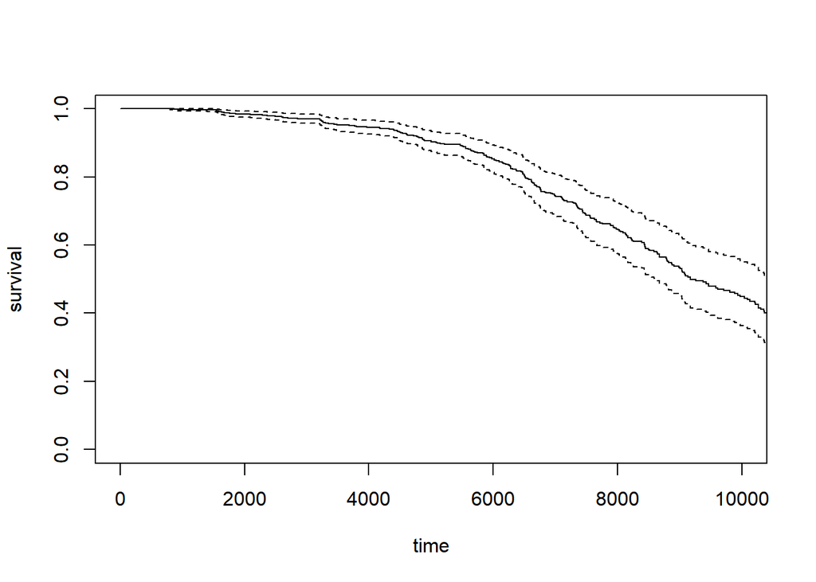

```r
predict<-survfit(test,c(share_holders_count=1,accounts_receivable=2500000 ))
plot(predict, xlab="time", ylab="survival",xlim = c(0,10000))
```

식으로 표현하면 아래와 같다.

부도난 기업 293, 부도나지 않은 기업 321 총 614개의 기업에 대해

```r
surv_day <- function(dt,prob) {
  Y = 0; N = 0
  for(i in 1:614){
    predict<-survfit(test,c(share_holders_count=dt$share_holders_count[i],
                            accounts_receivable=dt$accounts_receivable[i]))

    save = min(predict$time[which(abs(predict$surv-prob) == min(abs(predict$surv-prob)))])

    if(dt$failure[i] == 1){
      Y = Y+save} else {
        N = N + save
        }
  }
  result = c(Y/293,N/321)
  names(result) = c("bankruptcy_Y_day_mean","bankruptcy_N_day_mean")
  return(result)
}

surv_day(data2,0.3)
```

```
## bankruptcy_Y_day_mean bankruptcy_N_day_mean
##              10373.60              11051.63
```

```r
#survfit을 이용해서 확률을 구했는데 그 확률이 높은건지 낮은건지 알 수 없으니까 부도난 기업과 부도나지 않은 기업들의 평균으로 기준을 마련해주는 용도
surv_prob <- function(dt,day) {
  Y = 0; N = 0
  for(i in 1:614){
    predict<-survfit(test,c(share_holders_count=dt$share_holders_count[i],
                            accounts_receivable=dt$accounts_receivable[i]))

    save = predict$surv[which(abs(predict$time-day) == min(abs(predict$time-day)))]

    if(dt$failure[i] == 1){
      Y = Y+save} else {
        N = N + save
        }
  }
  result = c(Y/293,N/321)
  names(result) = c("bankruptcy_Y_prob_mean","bankruptcy_N_prob_mean")
  return(result)
}

surv_prob(data2,10000)
```

```
## bankruptcy_Y_prob_mean bankruptcy_N_prob_mean
##              0.3281778              0.3630121
```